# Assignment 10

Yerin Jung

7/27/2018

# 1 Data

```r
ccard <-read_csv("creditcard.csv")
```

## 1.1 Quick EDA

Just like I have done for the previous assignment, I looked at the summary statistics of credit card data and found two points to adjust.  
1. `Class` variable should be a factor rather than an integer. As such, I changed it to a factor.  
2. `Time` variable is not necessarily needed for this modeling. As such, I removed the entire column.

```r
ccard$Class <-as.factor(ccard$Class)
ccard <- ccard[,c(2:31)]
```

## 1.2 Down-Sampling

As we can see from the below table, we have an extremely unbalanced data.  
When we look at a table of `Class` variable, fraud class($1$) take only $0.173$%.

Since the minority case ($1$ case in this case) takes less than $1$%, it is highly likely for our future model to not detect these cases.  
For instance, even if we predict all of the cases as `non-fraud`, we will still be able to get more than $99$% accuracy.

Therefore,  
1. We need to do down-sampling to balance the imbalanced dataset.  
2. We need to come up with the right evaluation metrics later on.

```r
table(ccard$Class)
```

```
##
##      0      1
## 284315    492
```

This time, I slightly increased the samples size of `Class == 0`. I sampled $5500$ observations from the Class $0$.

```r
set.seed(101)
ccard_0case <- ccard %>% filter(Class=='0')

df2 <-ccard_0case[sample(nrow(ccard_0case), 5500), ]
df<-rbind(df2,ccard[ccard$Class=='1',])

table(df$Class)
```

```
##
##    0    1
## 5500  492
```

# 2 GBM Model

## 2.1 Modeling

```r
h2o.init(nthreads=-1, max_mem_size='4G')
```

After initializing the h2o,  
1. I changed the dataset into h2o data frame format,  
2. split the dataset into `train`, `valid`, and `test` set, and  
3. set the response and predictive variables respectively.

```r
df.hex <-as.h2o(df)

splits <- h2o.splitFrame(
  data = df.hex,
  ratios = c(0.2,0.2),
    destination_frames = c("train", "valid", "test"), seed = 101
)
train <- splits[[1]]
valid <- splits[[2]]
test  <- splits[[3]]

resp <- 'Class'
pred <- setdiff(names(df), resp)
```

I tried a modeling with random hyper-parameters, and then printed auc on the validation data.

```r
gbm <- h2o.gbm(x = pred, y = resp,
               training_frame = train,
               validation_frame = valid,
               learn_rate = .05, learn_rate_annealing =.99,
               ntrees=500,
               stopping_rounds = 5,
               stopping_tolerance = 1e-4,
               stopping_metric = "AUC",
               seed = 101)

print(h2o.auc(gbm, valid = TRUE))
```

## 2.2 Grid-Search

To find the best combination of hyper-parameters, I am going to conduct grid-search.

```r
hyper_params = list( ntrees = seq(100,1000,200),
                     max_depth=seq(2,15,3)
                     )


grid <- h2o.grid(
  hyper_params = hyper_params,

  search_criteria = list(strategy = "Cartesian"),

  algorithm="gbm",

  grid_id="my_grid",

  # Below are is the same as h2o.gbm()
  x = pred,
  y = resp,
  training_frame = train,
  validation_frame = valid,
  learn_rate = 0.05,
  learn_rate_annealing = 0.99,
  sample_rate=0.8,
  col_sample_rate=0.8,
  seed = 101,
  stopping_rounds = 5,
  stopping_tolerance = 1e-4,
  stopping_metric = "AUC",
  score_tree_interval = 10
)

grid
```

After doing the grid search, I sorted the model by descending order of AUC, to find the best model to use.

```r
## sort the grid models by decreasing AUC
sortedGrid <- h2o.getGrid("my_grid", sort_by="auc", decreasing = TRUE)
print(sortedGrid)
```

```
## H2O Grid Details
## ================
##
## Grid ID: my_grid
## Used hyper parameters:
##   -  max_depth
##   -  ntrees
## Number of models: 25
## Number of failed models: 0
##
## Hyper-Parameter Search Summary: ordered by decreasing auc
##   max_depth ntrees        model_ids                auc
## 1         5    900 my_grid_model_21 0.9796018089142681
## 2         5    500 my_grid_model_11 0.9796018089142681
## 3         5    700 my_grid_model_16 0.9796018089142681
## 4         5    300  my_grid_model_6 0.9794772544360556
## 5         5    100  my_grid_model_1 0.9751370099260339
##
## ---
##    max_depth ntrees        model_ids                auc
## 20        14    300  my_grid_model_9 0.9718171540259839
## 21         8    900 my_grid_model_22 0.9703751964128311
## 22         8    500 my_grid_model_12 0.9703751964128311
## 23         8    300  my_grid_model_7 0.9703751964128311
## 24         8    700 my_grid_model_17 0.9703751964128311
## 25         2    100  my_grid_model_0 0.9685452036944774
```

## 2.3 Best Model

I set the best model as the one with the highest AUC from the grid-search result.  
I printed the variable importance, the number of trees, and the maximum depth of the tree, used in my best model.

```r
best_model <- h2o.getModel(sortedGrid@model_ids[[1]])
top_5<-best_model@model$variable_importances$variable[1:5]
print( sprintf("The top 5 important variables: %s",paste(top_5,collapse=" ")))
```

```
## [1] "The top 5 important variables: V14 V10 V12 V4 V11"
```

```r
ntrees <- best_model@model$model_summary$number_of_trees
max_depth <- best_model@model$model_summary$max_depth
print( sprintf("In my best model, the number of trees is %s, and maximum depth of the tree is %s", ntrees, max_depth) )
```

```
## [1] "In my best model, the number of trees is 380, and maximum depth of the tree is 5"
```

If I compare the AUC results on validation data, we can find that the AUC has been improved.

```
## [1] "The AUC with random hyper parameters was: 0.963094"
```

```
## [1] "The AUC with the gird-search best model is: 0.979602"
```

Finally, I tested on my `test` data as well.

```r
my.perf = h2o.performance(best_model, test)

print( sprintf("MSE: %s, RMSE: %s, LogLoss: %s, AUC: %s, Gini: %s",
               round(my.perf@metrics$MSE,5),
               round(my.perf@metrics$RMSE, 5),
               round(my.perf@metrics$logloss,5),
               round(my.perf@metrics$AUC,5),
               round(my.perf@metrics$Gini,5))
       )
```

```
## [1] "MSE: 0.01229, RMSE: 0.11088, LogLoss: 0.0572, AUC: 0.9796, Gini: 0.95921"
```

## 2.4 ROC and Precision-Recall

I plotted both `ROC` and `Precision-Recall` curve as follows.

```r
tpr=as.data.frame(h2o.tpr(my.perf))
fpr=as.data.frame(h2o.fpr(my.perf))
ROC_out<-merge(tpr,fpr,by='threshold')


precision=as.data.frame(h2o.precision(my.perf))
recall=as.data.frame(h2o.recall(my.perf))
PR_out<-merge(precision,recall,by='threshold')
```

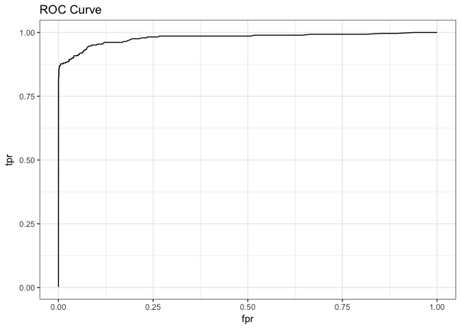

```r
ggplot(ROC_out, aes(x = fpr, y = tpr)) +
  theme_bw() +
  geom_line() +
  ggtitle("ROC Curve")
```

1. `ROC`: As we can see from the above plot, it is pretty much close to the top-left corner (Our AUC is around 0.97).

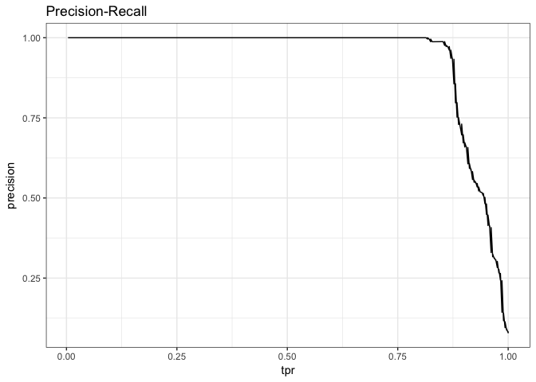

```r
ggplot(PR_out, aes(x = tpr, y = precision)) +
  theme_bw() +
  geom_line() +
  ggtitle("Precision-Recall")
```

2. `Precision-Recall`: I believe that since we have a quite imbalanced dataset, we better to look at the precision-recall curve since precision is directly influenced by class imbalance. Still, we can find that the graph is pretty much close to the upper-right corner, which is our optimum.

## 2.5 Variable Importance and Partial Dependence Plots

To conclude, I checked the Variable Importance and plotted Partial Dependence Plots.

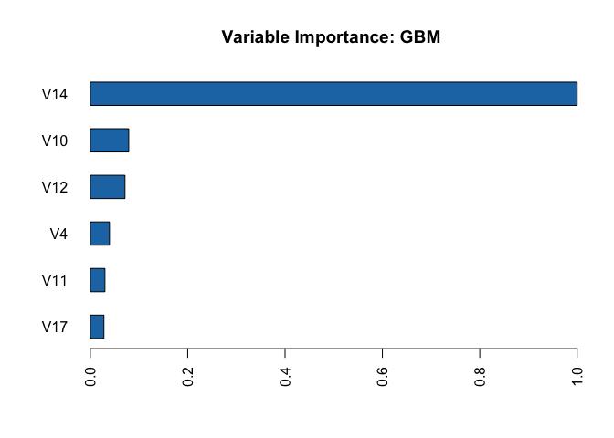

```r
h2o.varimp_plot(best_model, num_of_features = 6)
```

As we can see from the above plot, `V14` was the most important variable in this model.

Now I am going to plot partial dependence plots.

1. Top 6 Important Variables
- First, I plotted the top 6 important variables together.

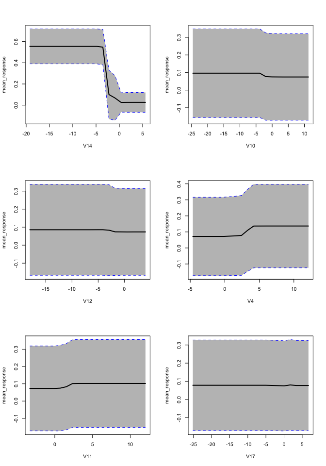

```r
h2o.no_progress()
imp_variables=best_model@model$variable_importances$variable[1:6]
par(mfrow=c(3,2))
imp_plot=h2o.partialPlot(object = best_model, data = test, cols = imp_variables, plot_stddev = TRUE)
```

Just as we were able to find from the Variable Importance plot,  
$V14$ showed the most significant impact on the response variable as we can see from the top-left plot.  
Even though the other variables were selected amongst top 6 important variables, the relationships are hardly noticeable, comparing to the $V14$.

2. The Other Variables
- I plotted the other variables (apart from top 6 important variables) altogether.

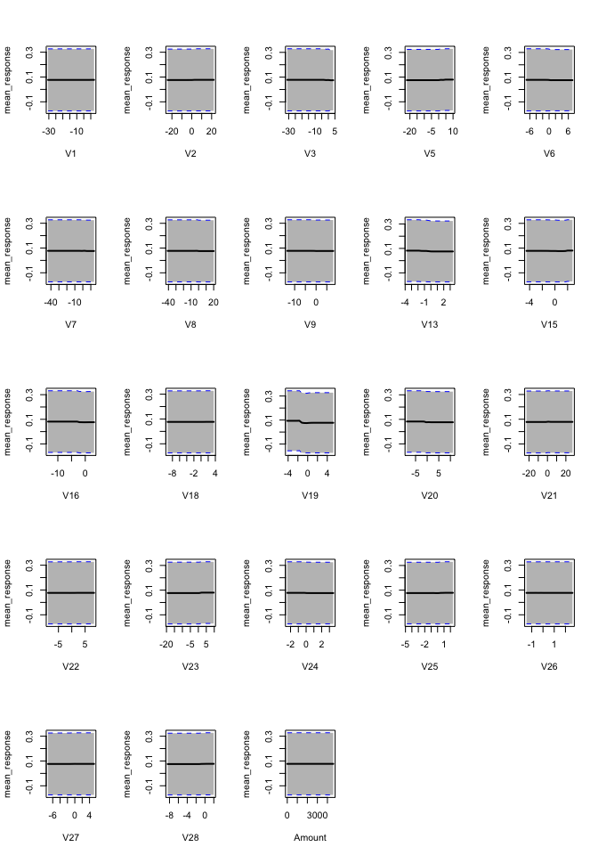

```r
h2o.no_progress()
par(mfrow=c(5,5))
less_variables=setdiff(names(ccard), c(imp_variables,"Class"))
less_plot=h2o.partialPlot(object = best_model, data = test, cols = less_variables, plot= TRUE, plot_stddev = TRUE)
```

As we can see from the above graphs, the less important variables have brought almost no change in the response variable.

If we plot without standard deviations, we can differentiate whether a predictive variable has positive or negative impact on the response variable.

1. Top 6 Important Variables

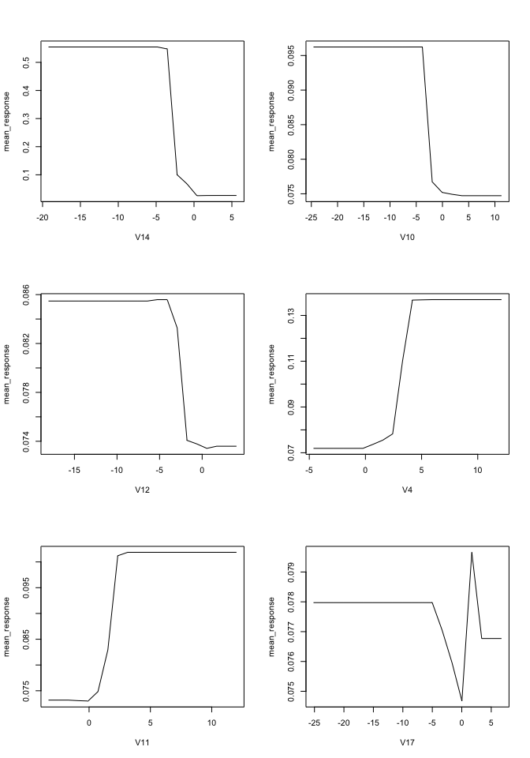

```r
h2o.no_progress()
imp_variables=best_model@model$variable_importances$variable[1:6]
par(mfrow=c(3,2))
imp_plot=h2o.partialPlot(object = best_model, data = test, cols = imp_variables, plot_stddev = FALSE)
```

2. The Other Variables

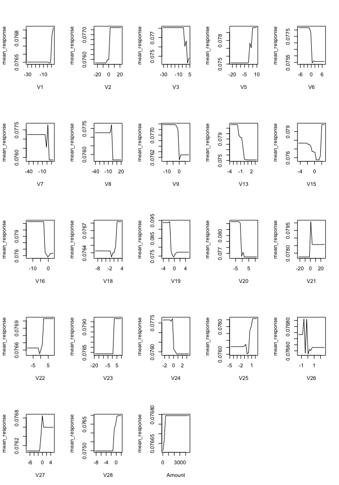

```r
h2o.no_progress()
par(mfrow=c(5,5))
less_variables=setdiff(names(ccard), c(imp_variables,"Class"))
less_plot=h2o.partialPlot(object = best_model, data = test, cols = less_variables, plot= TRUE, plot_stddev = FALSE)
```

```r
h2o.shutdown(prompt=FALSE)
```

```
## [1] TRUE
```